# R Notebook

`r`r library(Seurat) library(sctransform) library(tidyr) library(gdata) library(ggplot2)

matrix_dir = ‘/Volumes/Critical Care/Kernie Lab/Sana/Single Cell Project/Run1/internal_files/raw_feature_bc_matrix/’ MG <- Read10X(data.dir = matrix_dir) MG <- CreateSeuratObject(counts= MG, project = ‘SS01’) MG[[.mt]] <- PercentageFeatureSet(MG, pattern = ^mt-) MG <- subset(MG, subset = nFeature_RNA > 1000 & nCount_RNA >2500 &percent.mt < 20) MG <- SCTransform(MG, vars.to.regress = .mt, verbose = FALSE)

saveRDS(MG, file = ‘/Users/sanachintamen/Desktop/SS01.Rds’)

`r`r matrix_dir = ‘/Volumes/Critical Care/Kernie Lab/Sana/Single Cell Project/Run2 /output/SS002/cellranger_analysis_outs/raw_feature_bc_matrix/’ MG <- Read10X(data.dir = matrix_dir) MG <- CreateSeuratObject(counts= MG, project = ‘SS02’) MG[[.mt]] <- PercentageFeatureSet(MG, pattern = ^mt-) MG <- subset(MG, subset = nFeature_RNA > 1000 & nCount_RNA >2500 &percent.mt < 20) MG <- SCTransform(MG, vars.to.regress = .mt, verbose = FALSE)

saveRDS(MG, file = ‘/Users/sanachintamen/Desktop/SS02.Rds’)

`r`r matrix_dir = ‘/Volumes/Critical Care/Kernie Lab/Sana/Single Cell Project/Run3/cellranger_analysis_outs/raw_feature_bc_matrix/’ MG <- Read10X(data.dir = matrix_dir) MG <- CreateSeuratObject(counts= MG, project = ‘SS03’) MG[[.mt]] <- PercentageFeatureSet(MG, pattern = ^mt-) MG <- subset(MG, subset = nFeature_RNA > 1000 & nCount_RNA >2500 &percent.mt < 20) MG <- SCTransform(MG, vars.to.regress = .mt, verbose = FALSE)

saveRDS(MG, file = ‘/Users/sanachintamen/Desktop/SS03.Rds’)

`r`r keep(mg_list, sure = TRUE)

```
Error in keep(mg_list, sure = TRUE) : could not find function \keep\
```

`r`r features <- SelectIntegrationFeatures(object.list = mg_list, nfeatures = 3000) mg_list <- PrepSCTIntegration(object.list = mg_list, anchor.features = features) anchors <- FindIntegrationAnchors(object.list = mg_list, normalization.method = ‘SCT’, anchor.features = features)

saveRDS(anchors, file = ‘/Users/sanachintamen/Desktop/cx3cr1_anchors.Rds’)

`r`r rm(mg_list, features) samples.combined <- IntegrateData(anchorset= anchors, normalization.method = ‘SCT’)

`r`r rm(anchors) samples.combined <- RunUMAP(samples.combined, reduction = , dims = 1:40) clusters <- FindNeighbors(samples.combined, dims = 1:40) clusters <- FindClusters(clusters, resolution = 0.5)

saveRDS(clusters, file = ‘/Users/sanachintamen/Desktop/Cx3cr1_clusters.Rds’)

`r`r library(Seurat) library(ggplot2) library(patchwork) library(RColorBrewer) clusters <- readRDS(file = ‘/Users/sanachintamen/Desktop/Cx3cr1_clusters.Rds’, refhook = NULL)

#Note: compile CTCN colors before running DimPlot(clusters, label =TRUE) +CTCN_chroma(7) + theme_void() + NoLegend()

`r`r library(dplyr) library(paletteer) library(tidyr) DefaultAssay(clusters) <- ‘integrated’

meta <- clusters@meta.data meta <- as.data.frame(meta)

run1 <- filter(meta, orig.ident == ‘SS01’) run1 <- as.data.frame(table(run1$seurat_clusters)) run <- 'SS01' length(run) <- 14 run <- replace_na(run, 'SS01') run1 <- cbind(run, run1) colnames(run1) <-c('RunID', 'ClusterID', 'CellCount') totalcells <- sum(run1$CellCount) Percent <- ((run1$CellCount)/totalcells) * 100 Percent <- round(Percent, digits=2) run1 <- cbind(run1, Percent)

run2<- filter(meta, orig.ident == ‘SS02’) run2 <- as.data.frame(table(run2$seurat_clusters)) run <- 'SS02' length(run) <- 14 run <- replace_na(run, 'SS02') run2 <- cbind(run, run2) colnames(run2) <-c('RunID', 'ClusterID', 'CellCount') totalcells <- sum(run2$CellCount) Percent <- ((run2$CellCount)/totalcells) * 100 Percent <- round(Percent, digits=2) run2 <- cbind(run2, Percent)

run3<- filter(meta, orig.ident == ‘SS03’) run3 <- as.data.frame(table(run3$seurat_clusters)) run <- 'SS03' length(run) <- 14 run <- replace_na(run, 'SS03') run3 <- cbind(run, run3) colnames(run3) <-c('RunID', 'ClusterID', 'CellCount') totalcells <- sum(run3$CellCount) Percent <- ((run3$CellCount)/totalcells) * 100 Percent <- round(Percent, digits=2) run3 <- cbind(run3, Percent)

runs <- rbind(run1, run2, run3)

[figure not shown]

p <- VlnPlot(clusters, features = ‘nFeature_RNA’, pt.size = 0) + NoLegend() + ggtitle(‘Number of Unique Genes’) + xlab(‘ClusterID’) + CTCN_tint(‘mixed7’) p1 <- VlnPlot(clusters, features = ‘nCount_RNA’, pt.size = 0) + NoLegend() +ggtitle(‘Number of Transcripts’) + xlab(‘ClusterID’) +CTCN_tint(‘mixed7’)

`r`r library(dplyr) clusters <- readRDS(file = ‘/Users/sanachintamen/Desktop/Cx3cr1_clusters.Rds’, refhook = NULL) DefaultAssay(clusters) <- ‘RNA’

clusters <- NormalizeData(clusters) clusters <- FindVariableFeatures(clusters) all.genes <- rownames(clusters) clusters <- ScaleData(clusters, features = all.genes)

DGE <- FindAllMarkers(clusters, logfc.threshold = 0.25, min.pct = 0.7, only.pos = TRUE, assay = ‘RNA’)

p2f + CTCN_chroma(‘mixed7’)

`r`r library(Seurat) library(patchwork) library(ggplot2) clusters <- readRDS(file = ‘/Users/sanachintamen/Desktop/Cx3cr1_clusters.Rds’, refhook = NULL)

DefaultAssay(clusters) <- ‘RNA’ clusters <- NormalizeData(clusters) clusters <- FindVariableFeatures(clusters) all.genes <- rownames(clusters) clusters <- ScaleData(clusters, features = all.genes)

scheme <- c(#d5d0bc, #ff5e62)

# canonical markers

p1 <- FeaturePlot(clusters, features = ‘Tmem119’, cols = scheme)+ theme_void() + ggtitle(‘Tmem119’ ) + theme(plot.title = element_text(hjust = 0.5, face = ‘bold’))

p2 <- FeaturePlot(clusters, features = ‘Aif1’,cols = scheme) + theme_void() + ggtitle(‘Aif1’ ) + theme(plot.title = element_text(hjust = 0.5, face = ‘bold’))

p3 <-FeaturePlot(clusters, features = ‘Cd68’,cols = scheme)+ theme_void() + ggtitle(‘Cd68’ ) + theme(plot.title = element_text(hjust = 0.5, face = ‘bold’))

p4 <- FeaturePlot(clusters, features = ‘Xist’, cols = scheme)+ theme_void() + ggtitle(‘Xist’ ) + theme(plot.title = element_text(hjust = 0.5, face = ‘bold’))

# State specific signature

p5 <- FeaturePlot(clusters, features = ‘Apoe’,cols = scheme)+ theme_void() + ggtitle(‘Apoe’ ) + theme(plot.title = element_text(hjust = 0.5, face = ‘bold’))

p6 <- FeaturePlot(clusters, features = ‘Axl’,cols = scheme)+ theme_void() + ggtitle(‘Axl’ ) + theme(plot.title = element_text(hjust = 0.5, face = ‘bold’))

p7 <- FeaturePlot(clusters, features = ‘Egr1’, cols = scheme)+ theme_void() + ggtitle(‘Egr1’ ) + theme(plot.title = element_text(hjust = 0.5, face = ‘bold’))

p8 <- FeaturePlot(clusters, features = ‘Rtp4’, cols =scheme)+ theme_void() + ggtitle(‘Rtp4’ ) + theme(plot.title = element_text(hjust = 0.5, face = ‘bold’))

p9 <- FeaturePlot(clusters, features = ‘Mki67’, cols = scheme)+ theme_void() + ggtitle(‘Mki67’ ) + theme(plot.title = element_text(hjust = 0.5, face = ‘bold’))

p10 <- FeaturePlot(clusters, features = ‘Ttr’,cols = scheme)+ theme_void() + ggtitle(‘Ttr’ ) + theme(plot.title = element_text(hjust = 0.5, face = ‘bold’))

p11 <- FeaturePlot(clusters, features = ‘Pf4’, cols = scheme)+ theme_void() + ggtitle(‘Pf4’ ) + theme(plot.title = element_text(hjust = 0.5, face = ‘bold’))

p12 <- FeaturePlot(clusters, features = ‘Cd74’,cols = scheme)+ theme_void() + ggtitle(‘Cd74’ ) + theme(plot.title = element_text(hjust = 0.5, face = ‘bold’))

`r`r p0 <- VlnPlot(clusters, features = MG_markers, idents = c(0,1,4), pt.size = 0)

```
Error in VlnPlot(clusters, features = MG_markers, idents = c(0, 1, 4),  :
  could not find function \VlnPlot\
```

`r`r library(ggrepel) library(EnhancedVolcano)

SGZvsMG <- FindMarkers(clusters, ident.1 = 4, ident.2 = c(0,1), logfc.threshold = 0.25) SGZ <- FindMarkers(clusters, ident.1 = 4, logfc.threshold = 0.25)

p1 <- EnhancedVolcano(SGZvsMG, lab = rownames(SGZvsMG), x = ‘avg_log2FC’, y = ‘p_val_adj’, xlim = c(-1.5,3), pCutoff = 10e-32, FCcutoff = 0.5, pointSize = 2.0, labSize = 6.0, colAlpha = 1, gridlines.major = T, gridlines.minor = T, drawConnectors = T, widthConnectors = 0.1, boxedLabels = F, legendLabels=c(‘n.s.’,‘Log2FC’,‘adj p-val’, ‘adj p-val + log2FC’), legendPosition = ‘bottom’, legendLabSize = 12, legendIconSize = 2.0, title = NULL, subtitle = NULL)

p1 p2 <- EnhancedVolcano(SGZ, lab = rownames(SGZ), x = ‘avg_log2FC’, y = ‘p_val_adj’, pCutoff = 10e-32, FCcutoff = 0.5, pointSize = 3.0, labSize = 6.0, colAlpha = 1, legendLabels=c(‘Not sig.’,‘Log (base 2) FC’,‘p-value’, ‘p-value & Log (base 2) FC’), legendPosition = ‘right’, legendLabSize = 16, legendIconSize = 5.0) pdf(file = /Users/sanachintamen/Desktop/SGZ_volcanoplot.pdf, # The directory you want to save the file in width = 10, # The width of the plot in inches height = 14) # The height of the plot in inches

EnhancedVolcano(SGZ, lab = rownames(SGZ), x = ‘avg_log2FC’, y = ‘p_val_adj’, pCutoff = 10e-32, FCcutoff = 0.5, pointSize = 1.0, labCol = ‘black’, labFace = ‘bold’, boxedLabels = TRUE, colAlpha = 4/5, legendPosition = ‘right’, legendLabSize = 12, legendIconSize = 8.0, drawConnectors = TRUE, widthConnectors = 1.0, colConnectors = ‘black’)

dev.off()

write.csv(SGZ, file = ‘/Users/sanachintamen/Desktop/SGZ_DGE.csv’)

`r`r library(ggplot2) library(ggdendro) library(reshape2) DefaultAssay(clusters) <- ‘integrated’ MG_tree <- BuildClusterTree(clusters)

ggdendrogram(MG_tree)

PlotClusterTree(MG_tree, reorder = T ) p <- plot(MG_tree, type = ‘phylogram’)

hclust(MG_tree)

plot(MG_tree, xlim = c(1, 20), ylim = c(1,8))

hcd <- as.dendrogram(MG_tree)

cols <- c(#a9a9a9, #1f77b4, #ff7f0e, #2ca02c)

hclust(clusters)

p <- plot_ggdendro(clusters, direction = , scale.color = cols, label.size = 2.5, branch.size = 0.5, expand.y = 0.2)

## Gene ontology

For visualization click [here](http://yulab-smu.top/clusterProfiler-book/chapter12.html)

```r
library(Seurat)
library(topGO)
library("org.Mm.eg.db")
library(genefilter)
library(dplyr)
library(tidyr)
library(tidyselect)
library(ggplot2)
library(enrichplot)

clusters <- readRDS(file = '/Users/sanachintamen/Desktop/Cx3cr1_clusters.Rds', refhook = NULL)
DefaultAssay(clusters) <- 'RNA'
clusters <- NormalizeData(clusters)
clusters <- FindVariableFeatures(clusters)
all.genes <- rownames(clusters)
clusters <- ScaleData(clusters, features = all.genes)

SGZvsMG <- FindMarkers(clusters, ident.1 = 8, ident.2 = c(13,14), logfc.threshold = 0.25)
gene <- rownames(SGZvsMG)
SGZvsMG <- cbind(gene, SGZvsMG)
SGZvsMG <- as_data_frame(SGZvsMG)
#write.csv(SGZvsMG, file = '/Users/sanachintamen/Desktop/SGZvsMG.csv')

topDiffGenes <- function (genelist)
{
  return(genelist < 0.01)
}


UpGenes <- function (genelist)
{
  genes_up <- filter(genelist, avg_log2FC > 0)
  gene <- genes_up$gene
  genes_up <- as.numeric(genes_up$p_val_adj)
  names(genes_up) <- gene
  rm(gene)
  return(genes_up)
}


DownGenes <- function (genelist)
{
  genes_down <- filter(genelist, avg_log2FC < 0)
  gene <- genes_down$gene
  genes_down <- as.numeric(genes_down$p_val_adj)
  names(genes_down) <- gene
  rm(gene)
  return(genes_down)
}



up <- UpGenes(SGZvsMG)
down <- DownGenes(SGZvsMG)


annotation <- function(genelist)
{
GOdata <- new("topGOdata",
              description = 'test run', ontology = "BP",
              allGenes = genelist, geneSel = topDiffGenes,
              annot = annFUN.org,
              nodeSize = 10,
              mapping = 'org.Mm.eg.db',
              ID = 'symbol')
resultFisher <- runTest(GOdata,
                        algorithm = "classic",
                        statistic = "fisher")
resultKS <- runTest(GOdata,
                    algorithm = "classic",
                    statistic = "ks")
resultKS.elim <- runTest(GOdata,
                         algorithm = "elim",
                         statistic = "ks")
allRes <- GenTable(GOdata, classicFisher = resultFisher,
                           classicKS = resultKS,
                           elimKS = resultKS.elim,
                           orderBy = "elimKS",
                          ranksOf = "classicFisher",
                          topNodes = 200,
                          numChar = 200)
return(allRes)
}

downGO <- annotation(down)

upGO <- annotation(up)
```

```r
p0 <-


ggplot(neuronup, aes(x =Annotated,y = reorder(Term, Annotated))) +
  theme_voidl()+
  geom_col(fill = 'forestgreen')  +
  theme(text = element_text(size = 10))
```

```
Error in theme_voidl() : could not find function "theme_voidl"
```

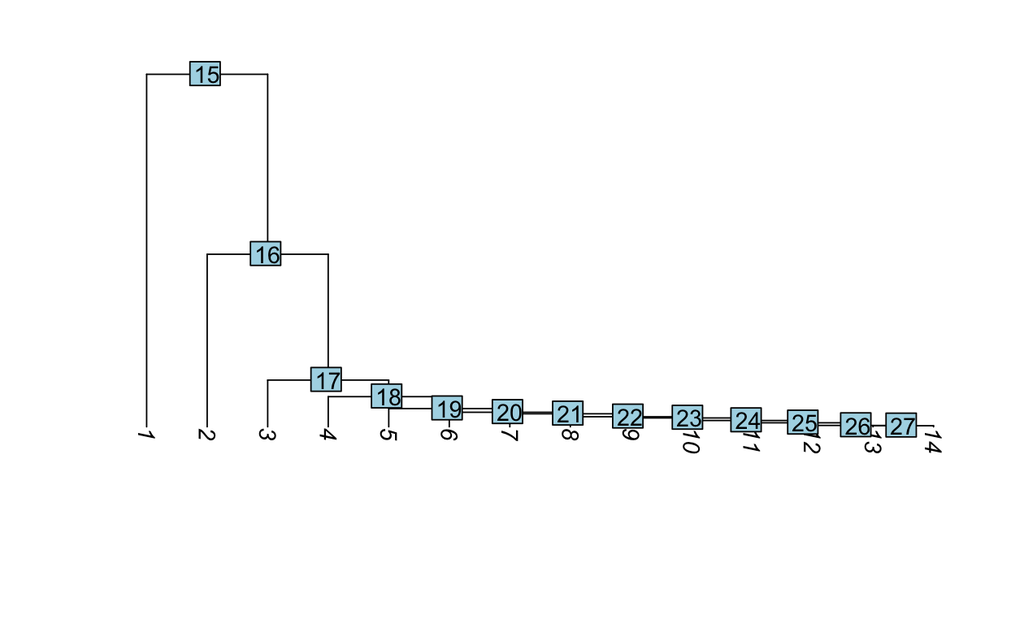

```r
#can use same parameteres as plot.phylo {ape}
PlotClusterTree(MG_tree) +RotatedAxis()
```